# SHAP-Based Explainability for Time-to-Event Pipelines

ml4time2event team

2025-12-14

# Introduction

The refactored `ml4time2event` exposes tidy predictions for both survival and competing-risk outcomes. `ml4t2e_calculate_shap()` layers expected-time-lost SHAP values on top of those predictions so you can interpret ensemble pipelines with a consistent grammar:

1. build a pipeline via `ml4t2e_pipeline()`
2. compute SHAP values with `ml4t2e_calculate_shap()`
3. visualise them using the helper plots (`ml4t2e_shap_importance()`, `ml4t2e_shap_dependence()`, `ml4t2e_shap_waterfall()`)

Expected time lost integrates the event probability up to a user-defined horizon. For survival models this is $\int_0^T (1 - S(t))\, dt$; for competing risks it is $\int_0^T \text{CIF}(t)\, dt$. The result is a scalar that SHAP can decompose exactly into feature-level contributions.

We rely on `fastshap` for Monte-Carlo SHAP estimation.

```r
library(ml4time2event)
library(dplyr)
library(ggplot2)
library(fastshap)
```

# Survival pipeline example

## Fit pipeline

```r
lung <- get_lung_survival_data()

if (is.data.frame(lung$status)) {
  lung$status <- lung$status[[1]]
}

status_max <- max(lung$status, na.rm = TRUE)
if (status_max > 1L) {
  lung$status <- ifelse(lung$status == status_max, 1L, 0L)
}

lung$status <- as.integer(lung$status)

surv_pipe <- ml4t2e_pipeline(
  outcome = list(type = "survival", time = "time", event = "status"),
  models = c("cox", "random_forest"),
  ensemble = "auto"
)

surv_pipe$fit(lung)
surv_pipe$summary()
```

```
## $outcome
## $outcome$type
## [1] "survival"
##
## $outcome$time
## [1] "time"
##
## $outcome$event
## [1] "status"
##
##
## $models
## [1] "cox"           "random_forest"
##
## $ensemble
## [1] "auto"
##
## $features
## [1] "age"              "sex"              "ph.ecog"          "ph.karno"
## [5] "pat.karno"        "meal.cal"         "wt.loss"          "age_group"
## [9] "performance_good"
##
## $training_metrics
##           model  metric     value
## 1           cox c_index 0.6553413
## 2           cox     ibs 0.1478021
## 3 random_forest c_index 0.6735285
## 4 random_forest     ibs 0.1446403
## 5      ensemble c_index 0.6762766
## 6      ensemble     ibs 0.1427669
##
## $resampling_results
## NULL
```

## Compute SHAP values

```r
set.seed(42)
surv_shap <- ml4t2e_calculate_shap(
  object = surv_pipe,
  data = lung[1:20, ],
  time_horizon = 365,
  nsim = 10
)
```

[output not shown]

```r
surv_shap
```

```
## $shap_values
##              age        sex    ph.ecog    ph.karno  pat.karno  meal.cal
##  [1,]  4.4255934   6.311750  -6.395235  1.46479343 -15.268546 -2.057063
##  [2,]  0.1677022   5.506808 -27.014241  1.14690766 -10.360341 -2.245177
##  [3,] -1.3635931   5.390192 -26.454548  0.96003357 -10.387009 -2.140933
##  [4,] -0.8929703   6.618340  -6.485157  2.64314262  27.284481 -1.589184
##  [5,] -0.7904485   5.717613 -27.968252  5.07707231 -11.358921 -2.436692
##  [6,]  3.5529086   6.096728  -6.355730 -2.50455039  -3.857598  1.716497
##  [7,] -0.1461296 -19.180215  20.959794 -1.38977940  23.777060  4.220196
##  [8,]  1.2539791 -18.557288  19.957332 -1.95609251  -3.531079  2.338843
##  [9,] -1.6451712   5.891505  -6.254734 -0.98114599  -3.519850 -1.683278
## [10,] -0.5216880   6.715862  21.594470 -2.10817977   5.410923 10.683140
## [11,] -1.4335815   6.068380  -6.367033 -0.09301293  -2.688339 -2.332592
## [12,] -0.1754365 -18.436039  19.780217 -1.49503355   5.536674  1.510656
## [13,]  0.2152639 -17.359071  -6.064074  1.41999229 -10.681431 -2.134296
```

[output cut: 110 more lines]

## Visualise

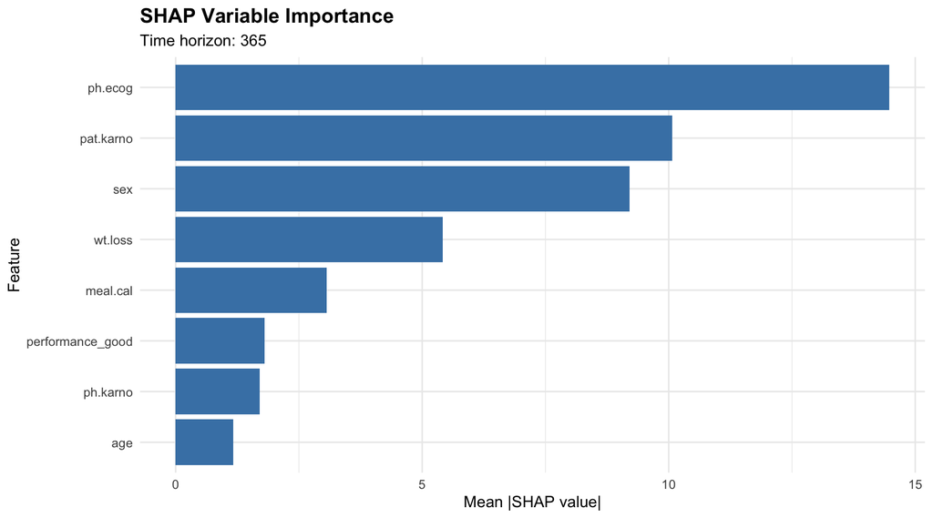

```r
ml4t2e_shap_importance(surv_shap, plot_type = "bar", max_features = 8)
```

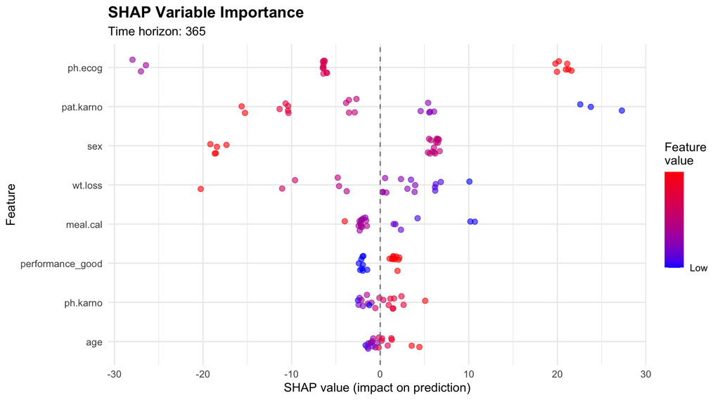

```r
ml4t2e_shap_importance(surv_shap, plot_type = "beeswarm", max_features = 8)
```

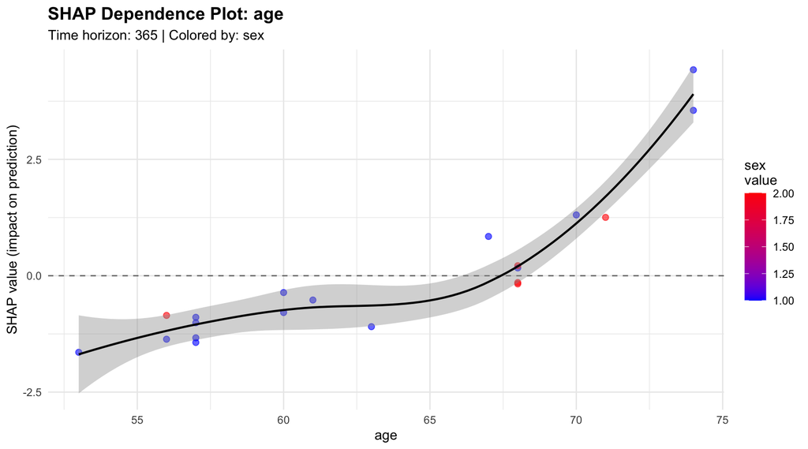

```r
ml4t2e_shap_dependence(surv_shap, feature = "age")
```

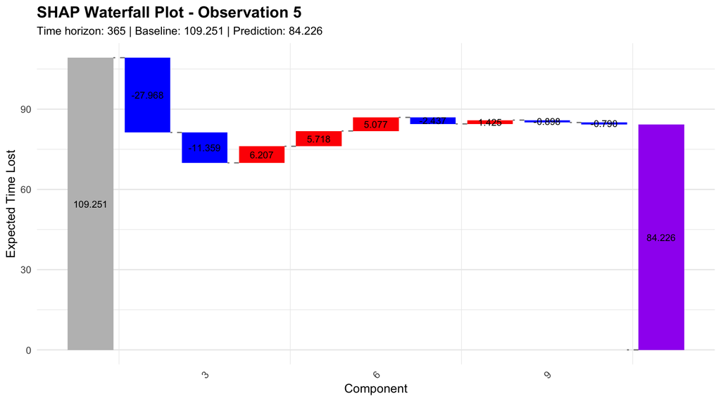

```r
ml4t2e_shap_waterfall(surv_shap, obs_id = 5, max_features = 8)
```

# Competing-risk pipeline example

## Fit pipeline

```r
bmt <- get_bmt_competing_risks_data() |>
  mutate(
    cause = if_else(status == 0L, NA_integer_, status),
    status = if_else(status == 0L, 0L, 1L)
  )

cr_pipe <- ml4t2e_pipeline(
  outcome = list(
    type = "competing_risk",
    time = "ftime",
    status = "status",
    cause = "cause"
  ),
  models = c("cox", "cr_fine_gray"),
  ensemble = "auto"
)

cr_pipe$fit(bmt)
cr_pipe$summary()
```

```
## $outcome
## $outcome$type
## [1] "competing_risk"
##
## $outcome$time
## [1] "ftime"
##
## $outcome$status
## [1] "status"
##
## $outcome$cause
## [1] "cause"
##
##
## $models
## [1] "cox"          "cr_fine_gray"
##
## $ensemble
## [1] "auto"
##
## $features
## [1] "sex"    "d"      "phase"  "age"    "source"
##
## $training_metrics
##        model cause  metric     value
## 1        cox     1     ibs 0.1654581
## 2        cox     1 c_index 0.7125210
## 3        cox     2     ibs 0.2060900
## 4        cox     2 c_index 0.6286605
## 5  fine_gray     1     ibs 0.1642618
## 6  fine_gray     1 c_index 0.7217647
## 7  fine_gray     2     ibs 0.2062046
## 8  fine_gray     2 c_index 0.6233682
## 9   ensemble     1     ibs 0.1646559
## 10  ensemble     1 c_index 0.7200840
## 11  ensemble     2     ibs 0.2059747
## 12  ensemble     2 c_index 0.6273668
##
## $resampling_results
## NULL
```

## Compute SHAP values

```r
set.seed(99)
cr_shap <- ml4t2e_calculate_shap(
  object = cr_pipe,
  data = bmt[1:20, ],
  time_horizon = 100,
  nsim = 10
)
```

[output not shown]

```r
cr_shap
```

```
## $shap_values
##             sex          d      phase        age        source
##  [1,] -1.644793  0.8282169   8.870459  7.9081481 -4.551914e-15
##  [2,]  6.177367 -4.0730884  -3.516762  1.1119874  1.387779e-16
##  [3,] -3.604567  1.9072428  -4.422190 -8.4566201  5.273559e-15
##  [4,]  5.556164  1.2708553  -2.967607  2.6776224 -8.604228e-16
##  [5,]  5.065891  1.1122817  -2.167359  7.8699414  2.220446e-16
##  [6,] -2.246742  1.6363692  14.397577 -1.4446695  1.004752e-14
##  [7,] -3.734503  1.7657607 -13.379519 -9.0855086  4.163336e-16
##  [8,]  6.125170  1.5228193 -11.242636 -2.8684770  3.955170e-15
##  [9,] -3.641331  1.5122453 -12.026475  2.6201423 -1.165734e-15
## [10,]  4.094070  1.4480522  13.318548 -4.2516649  4.440892e-16
## [11,] -1.940289  1.2463195  12.432827  3.0509242  4.649059e-16
## [12,] -3.021756 -5.4834246  14.690123 -4.3753860  4.718448e-16
## [13,]  5.906562 -3.7603915  -2.986684  4.8589306 -3.885781e-16
## [14,] -2.588058  1.8550779  15.465760 -5.7990378 -9.048318e-15
## [15,] -1.779365  0.8903116  10.271902  6.1411605  2.164935e-15
## [16,]  5.775200  1.3754787  -3.521730 -0.7616835 -8.243406e-15
## [17,] -3.537102  1.7260831  -4.220536 -2.2569628  9.159340e-16
## [18,] -3.769799 -4.4915264 -11.930919  4.9330493  7.546481e-15
## [19,] -3.729632  1.7784724 -13.421723 -9.6269201  9.436896e-16
## [20,] -3.462488 -4.0671557  -3.643057  7.7550239 -6.078471e-15
##
## $baseline
## [1] 81.06104
##
## $predictions
##  [1] 97.02307 80.76054 66.48490 87.59807 92.94179 93.40357 56.62727 74.59791
##  [9] 69.52562 95.67004 95.85082 82.87059 85.07945 89.99478 96.58504 83.92830
## [17] 72.77252 65.80184 56.06123 77.64336
##
## $feature_values
##    sex   d   phase age source
## 1    M ALL Relapse  48  BM+PB
## 2    F AML     CR2  23  BM+PB
## 3    M ALL     CR3   7  BM+PB
## 4    F ALL     CR2  26  BM+PB
## 5    F ALL     CR2  36  BM+PB
## 6    M ALL Relapse  17  BM+PB
## 7    M ALL     CR1   7  BM+PB
```

[output cut: 32 more lines]

```
## 1        cox     1     ibs 0.1654581
## 2        cox     1 c_index 0.7125210
## 3        cox     2     ibs 0.2060900
## 4        cox     2 c_index 0.6286605
## 5  fine_gray     1     ibs 0.1642618
## 6  fine_gray     1 c_index 0.7217647
## 7  fine_gray     2     ibs 0.2062046
## 8  fine_gray     2 c_index 0.6233682
## 9   ensemble     1     ibs 0.1646559
## 10  ensemble     1 c_index 0.7200840
## 11  ensemble     2     ibs 0.2059747
## 12  ensemble     2 c_index 0.6273668
##
## attr(,"class")
## [1] "ml4t2e_shap" "list"
```

## Visualise

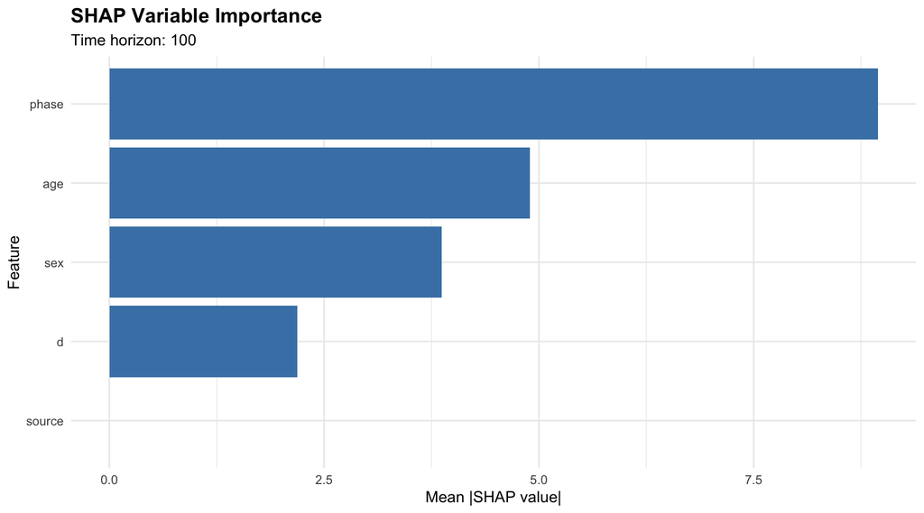

```r
ml4t2e_shap_importance(cr_shap, plot_type = "bar", max_features = 8)
```

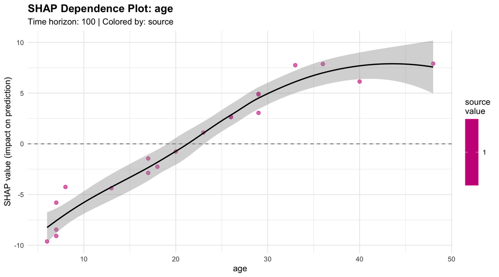

```r
ml4t2e_shap_dependence(cr_shap, feature = "age")
```

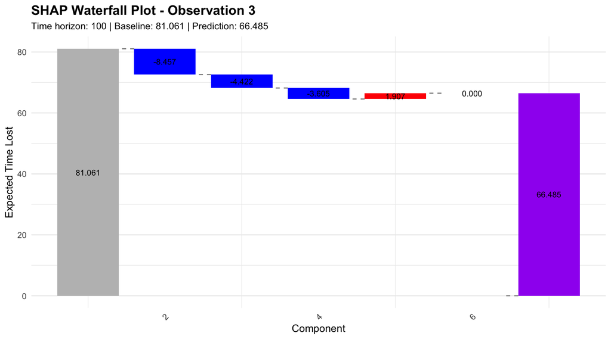

```r
ml4t2e_shap_waterfall(cr_shap, obs_id = 3, max_features = 6)
```

# Tips

- Increase `nsim` for smoother SHAP estimates once you move beyond vignette-sized examples.
- The helper returns the baseline prediction (expected time lost with all features off); this makes it easy to confirm the additivity constraint: prediction = baseline + Σ SHAP.
- For larger pipelines, subset the data before calling `ml4t2e_calculate_shap()` to keep runtimes manageable.

The SHAP helpers respect the tidy outputs of the new API, so they work equally well with survival or competing-risk pipelines.